# Dados Proteomica

Yasmine

24 de agosto de 2016

# Objetivo

Verificar-se-á entre as proteínas identificadas, quais tem abundância diferentes quando comparamos os controles aos pacientes afetados.

Começar-se-á pela leitura dos dados:

```r
library(readxl)
tbl=read_excel("20160718_BPDunifesp_proteinsmeasurements_nofilter.xlsx", skip=2)
tabela=tbl[,-c(2,4:11)]
tab=tabela[which(tbl$`Unique peptides`>=5),]
tab=tab[,-2]
dados=apply(tab[,-1], 2, as.double)
row.names(dados)=tab[[1]]
rm(tab, tbl, tabela)
```

Analisou-se somente os “Controles” e “Afetados”. E para enxergar-se melhor o comportamento dos dados, aplicou-se uma transformação aos mesmos. Somou-se 1 a todos os valores e calculou-se o log em base 2 do resultado dessa soma, para todos os casos.

```r
tran = function(x) log2(x+1)
n.dados=apply(dados, 2, tran)
```

Graficou-se a densidade para as transformações.

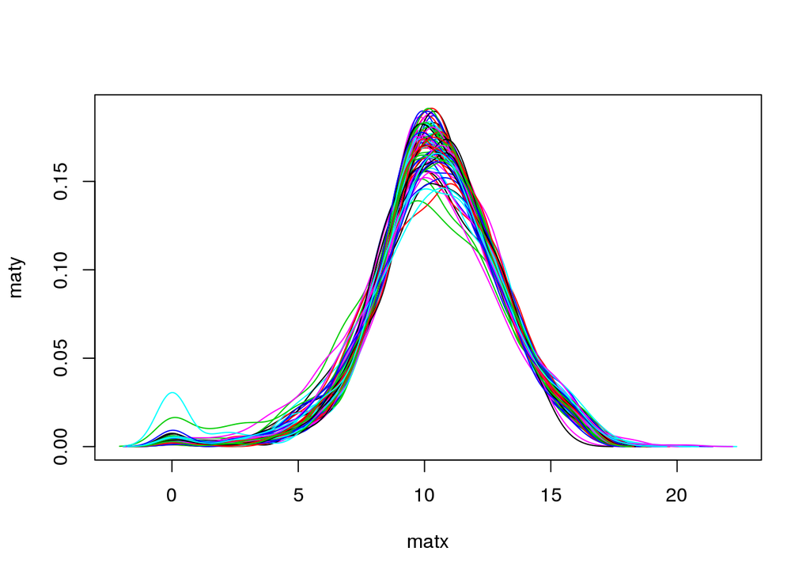

```r
fit=apply(n.dados, 2, density)
matx=sapply(fit, '[[', 'x')
maty=sapply(fit, '[[', 'y')
matplot(matx,maty, type='l', lty=1)
```

```r
rm(fit)
```

As correlações podem ser estudadas entre cada réplica de cada indivíduo. Para mostrar tais correlações elaborou-se alguns gráficos.

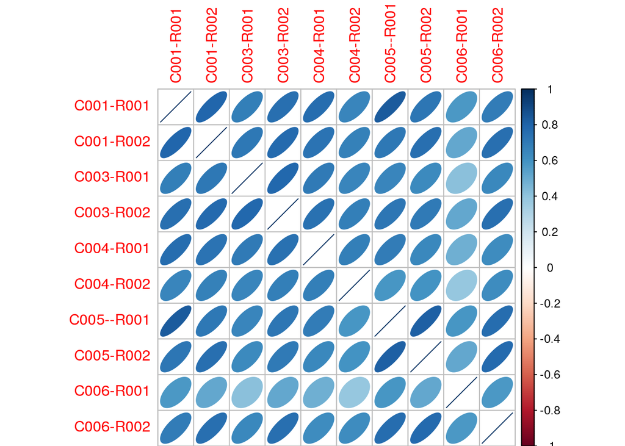

Gráfico de correlação entre as réplicas de cada indivíduo

```r
library(corrplot)
data=as.data.frame(n.dados)
x=cor(data[,1:10])
corrplot(x, method="ellipse")
```

```r
rm(x)
```

Garantiu-se que as correlações calculadas para cada individuo entre suas réplicas as foram feitas corretamente. O que se foi certificado ao se assegurar de que existam para cada indivíduo, seja ele controle ou paciente afetado, duas réplicas.

```r
nms=colnames(dados)
nms=gsub("--", "-", nms)
amostras = sapply(strsplit(nms, "-"), '[', 1)
replicas = sapply(strsplit(nms, "-"), '[', 2)
#table(amostras, replicas)
rm(nms, amostras, replicas)
```

Observou-se que somente o paciente 73B não possuia duplicata, portanto não se analisou tal indivíduo.

Então calcular-se-á corretamente as correlações par a par.

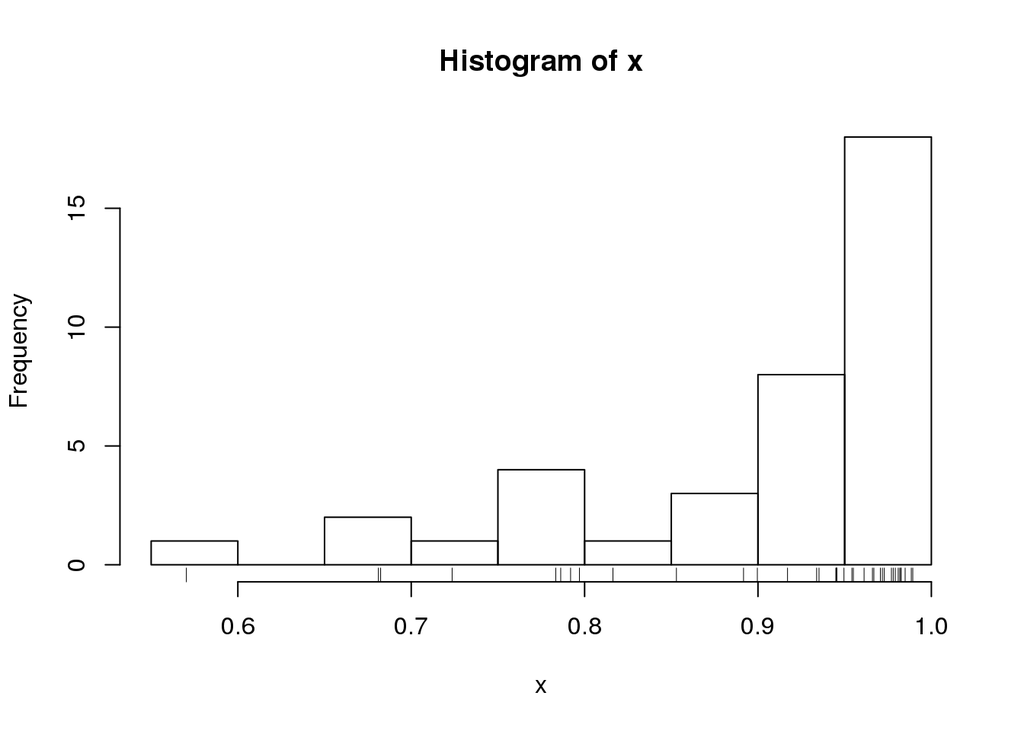

```r
data=data[,-75]
x=rep(0,length(data)/2)
for (i in 1:(length(data)/2)) {
  x[i]=cor(data[,2*i-1],data[,2*i])
}
hist(x)
rug(x)
```

```r
rm(i, x)
```

```r
pd=data.frame(id=names(data),
           status=ifelse (grepl("^C", names(data)), "controle", "caso"),
           replica=ifelse (grepl("1$", names(data)), "1", "2"))
```

Analizar-se-á as proteínas com o pacote de $Limma$.

```r
library("limma")
library("DT")
status=model.matrix(~status+replica, data = pd)
fit=lmFit(as.matrix(data), design=status)
cfit=eBayes(fit)
topP=topTable(cfit, coef = 2, number=Inf)
datatable(topP)
```

|  | logFC | AveExpr | t | P.Value | adj.P.Val | B |
| --- | --- | --- | --- | --- | --- | --- |
| Q9NZR2;A0A087WUR9;H0Y7T7 | 2.04432190616888 | 10.7404986918717 | 10.8975686033019 | 3.13478893677597e-17 | 2.43259621493815e-14 | 28.6756366450962 |
| O75165;H0Y8Q2 | -0.911145573925499 | 14.279252814845 | -8.00300328293992 | 1.04256626778399e-11 | 4.02071847900882e-09 | 16.3917103782295 |
| Q96M86 | 1.27524502761445 | 9.92722212544014 | 7.91262683131245 | 1.55440147384362e-11 | 4.02071847900882e-09 | 16.0051484375818 |
| Q8IZX4;H7BY98;H7C2K9 | -1.08619455765532 | 13.8554061731624 | -7.71157228909941 | 3.77493285543663e-11 | 5.89694461580267e-09 | 15.1464256148081 |
| Q58EX7;H3BME5;H3BPQ5;H3BQ60;H3BQE6;H3BQP9;H3BSU4 | 1.93881425624775 | 10.4043255009127 | 7.71009609756288 | 3.7995777163677e-11 | 5.89694461580267e-09 | 15.1401281039525 |
| Q53LP3 | 1.82759277136258 | 8.65194069913967 | 7.26297852857065 | 2.70925473653293e-10 | 3.50396945924925e-08 | 13.2394796133542 |
| Q9NX02;A0A0G2JLQ8;A0A0G2JLX3;A0A0G2JMG8;A0A0G2JNC8;A0A0G2JP37;A0A0G2JPB6;A0A0G2JPQ2;F5H5B1;F5H7Q5;J3KN39;K7EJ90;K7ELX1 | 2.19052304678198 | 11.8795061823908 | 7.10150394850655 | 5.48515773699321e-10 | 6.08068914843819e-08 | 12.5572623173559 |
| Q2LD37;H0Y781;H3BLT5 | -0.985469479183154 | 8.89941965698061 | -7.02134880951049 | 7.7772358981773e-10 | 7.54391882123198e-08 | 12.2196436897712 |
| P49321;E9PAU3;E9PI86;E9PJQ2;E9PKR5;E9PNB5;E9PPR5;E9PQG5;E9PRH9;Q5T624 | 0.734625968347613 | 9.55179899220895 | 6.85695884505045 | 1.58788156728197e-09 | 1.36910677356757e-07 | 11.5296261971423 |
| Q709C8;P29992 | -1.22033867642708 | 13.0799958702205 | -6.07473547944798 | 4.48878002488799e-08 | 3.48329329931308e-06 | 8.30390892257542 |

[output cut: 766 more lines]

Gráfico 1

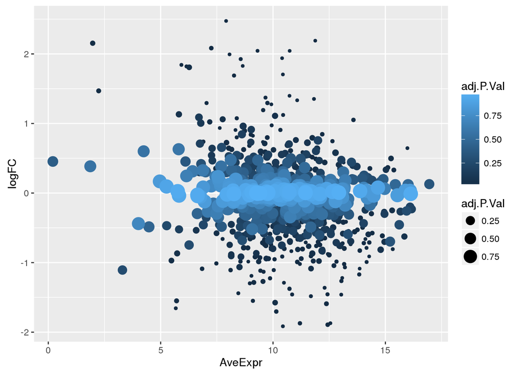

```r
library(ggplot2)
ggplot(topP, aes(x=AveExpr, y=logFC, colour=adj.P.Val, size=adj.P.Val )) + geom_point()
```

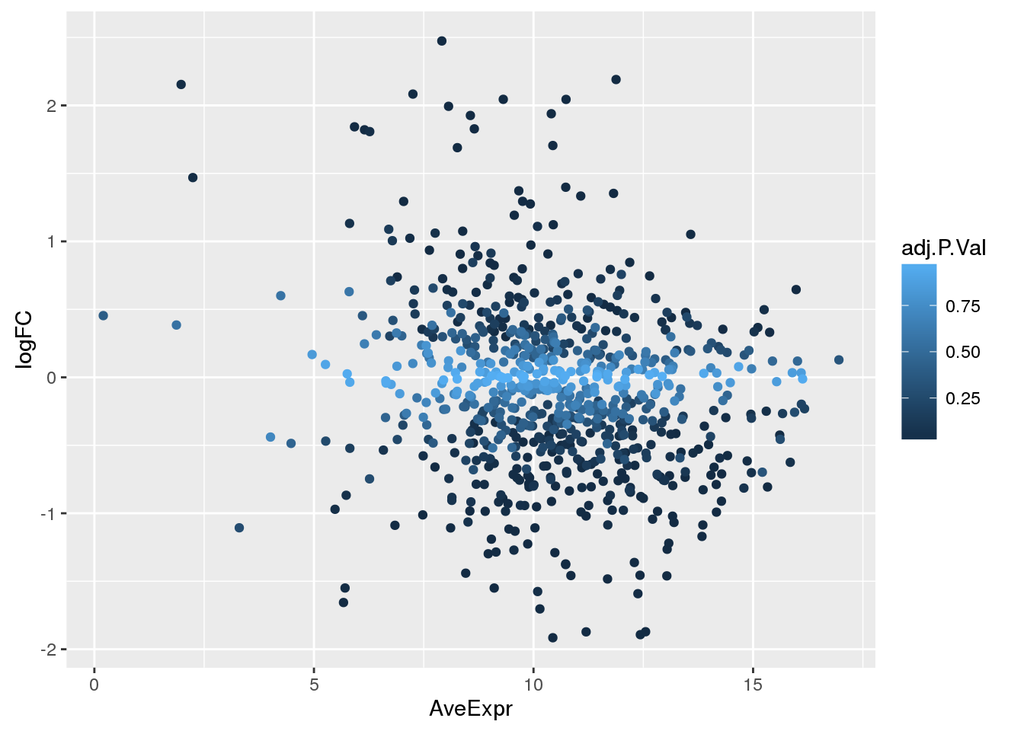

```r
ggplot(topP, aes(x=AveExpr, y=logFC, colour=adj.P.Val)) + geom_point()
```

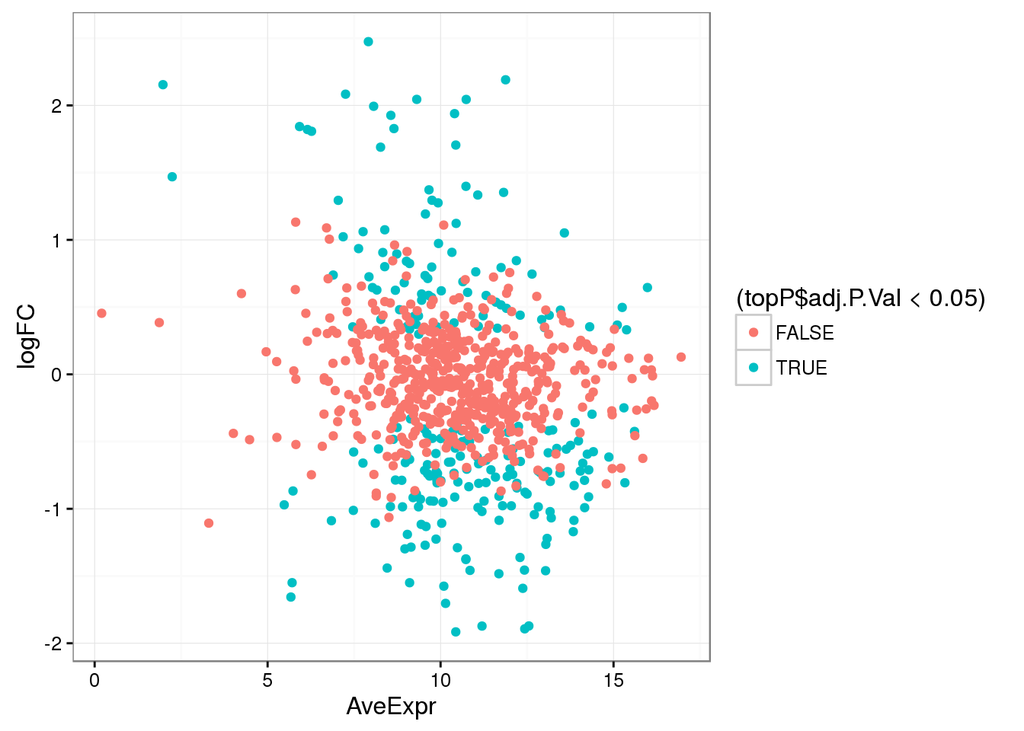

```r
ggplot(topP, aes(x=AveExpr, y=logFC, col=(topP$adj.P.Val<0.05))) + geom_point() + theme_bw()
```

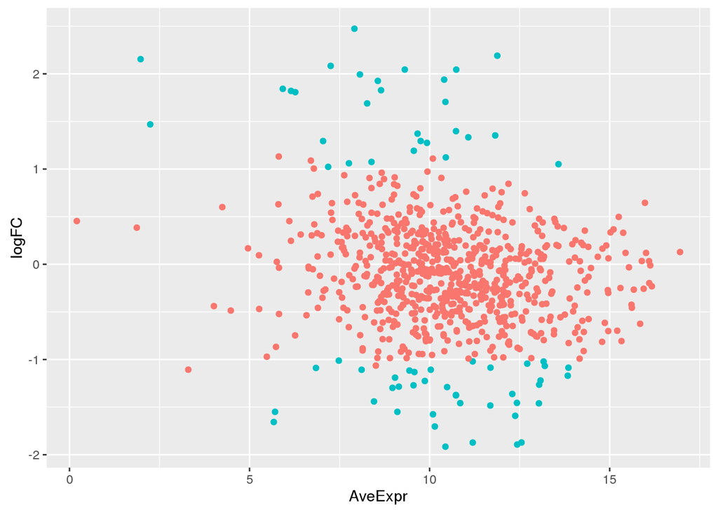

```r
ggplot(topP, aes(x=AveExpr, y=logFC, col=((abs(topP$logFC)>1)&(topP$adj.P.Val<0.05)))) + geom_point() + theme(legend.position="none")
```

Gráfico 2

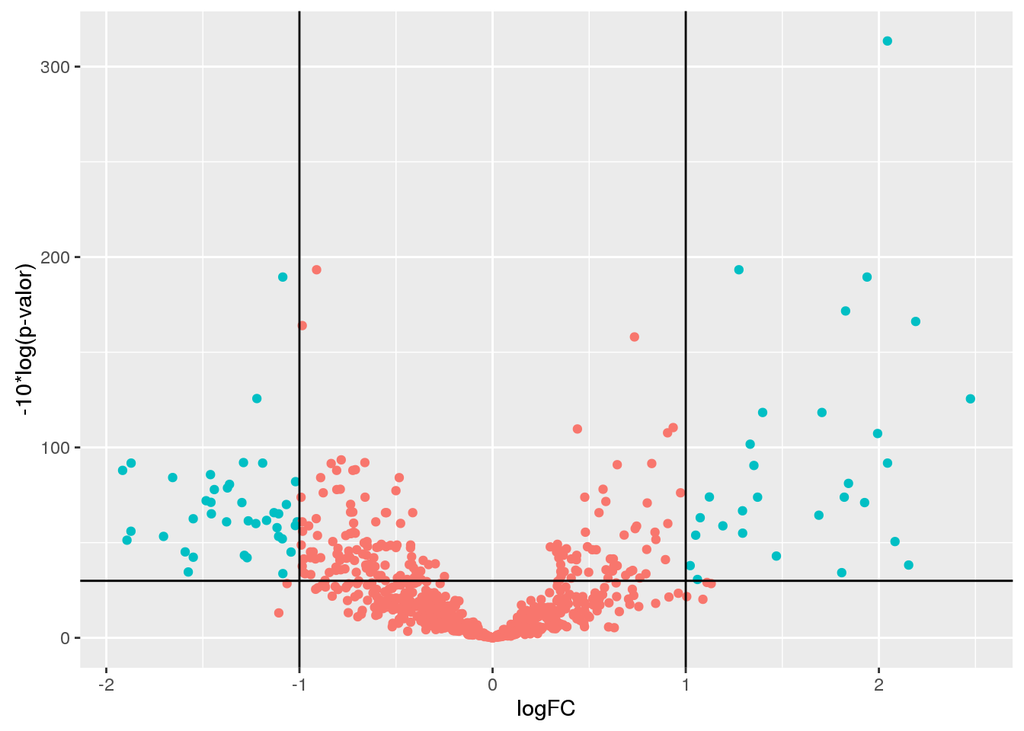

```r
ggplot(topP, aes(x=logFC, y=(-(10*log(adj.P.Val))), col=((abs(topP$logFC)>1)&((-10*log(topP$adj.P.Val))>-10*log(0.05))))) + geom_point() + geom_vline(xintercept = c(-1,1)) + geom_hline(yintercept = -10*log(0.05))  + ylab("-10*log(p-valor)") + theme(legend.position="none")
```

Vamos remover as proteínas cujo nome possui ‘REVERSE’ e estudar o efeito de tal remoção:

```r
#dados sem reverse
srev=data[-which((grepl("reverse", tolower(rownames(data))))),]
#dados com reverse
rev=data[which((grepl("reverse", tolower(rownames(data))))),]
```

Agora vamos restrigir o nome da proteína ao primeiro nome:

```r
nms=rownames(srev)
prot = sapply(strsplit(nms, ";"), '[', 1)
rownames(srev)=prot
rm(prot, nms)
```

E vamos repetir as análises:

```r
pd_srev=data.frame(id=names(srev),
           status=ifelse (grepl("^C", names(srev)), "controle", "caso"),
           replica=ifelse (grepl("1$", names(srev)), "1", "2"))
```

```r
library("limma")
library("DT")
status_srev=model.matrix(~status+replica, data = pd_srev)
fit2=lmFit(as.matrix(srev), design=status_srev)
cfit2=eBayes(fit2)
topP2=topTable(cfit2, coef = 2, number=Inf)
datatable(topP2)
```

|  | logFC | AveExpr | t | P.Value | adj.P.Val | B |
| --- | --- | --- | --- | --- | --- | --- |
| Q9NZR2 | 2.04432190616888 | 10.7404986918717 | 10.9009948786775 | 3.09677031674311e-17 | 2.15225537013646e-14 | 28.7582161262876 |
| O75165 | -0.911145573925499 | 14.279252814845 | -8.01120026297392 | 1.00666847782907e-11 | 3.49817296045602e-09 | 16.4249910726911 |
| Q96M86 | 1.27524502761445 | 9.92722212544014 | 7.91627579538715 | 1.53132519679424e-11 | 3.54757003924e-09 | 16.0169929172441 |
| Q8IZX4 | -1.08619455765532 | 13.8554061731624 | -7.71646529429886 | 3.69839184063426e-11 | 5.26363298799567e-09 | 15.1594825432171 |
| Q58EX7 | 1.93881425624775 | 10.4043255009127 | 7.71110690333067 | 3.78678632229905e-11 | 5.26363298799567e-09 | 15.1365149535375 |
| Q53LP3 | 1.82759277136258 | 8.65194069913967 | 7.26392850072371 | 2.70049690667488e-10 | 3.12807558356507e-08 | 13.2268503984272 |
| Q9NX02 | 2.19052304678198 | 11.8795061823908 | 7.10188726470066 | 5.4807250369719e-10 | 5.44157700099353e-08 | 12.5391887126278 |
| Q2LD37 | -0.985469479183154 | 8.89941965698061 | -7.02584060084691 | 7.63307190668535e-10 | 6.6312312189329e-08 | 12.2174501883324 |
| P49321 | 0.734625968347613 | 9.55179899220895 | 6.8649793964626 | 1.5348539262202e-09 | 1.18524830969227e-07 | 11.5391958444668 |
| Q709C8 | -1.22033867642708 | 13.0799958702205 | -6.07632404234576 | 4.46136155369829e-08 | 3.10064627982031e-06 | 8.27293365715707 |

[output cut: 685 more lines]

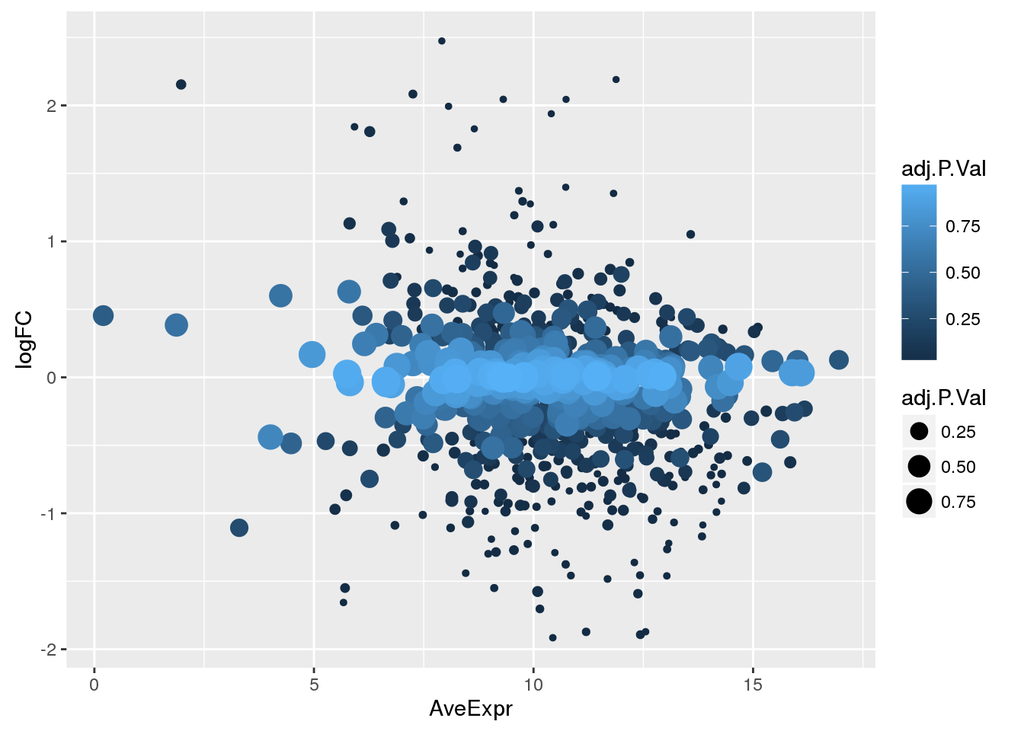

```r
library(ggplot2)
ggplot(topP2, aes(x=AveExpr, y=logFC, colour=adj.P.Val, size=adj.P.Val )) + geom_point()
```

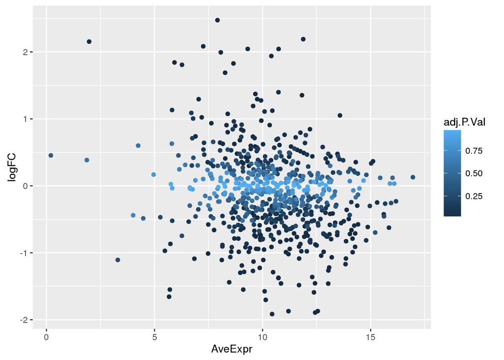

```r
ggplot(topP2, aes(x=AveExpr, y=logFC, colour=adj.P.Val)) + geom_point()
```

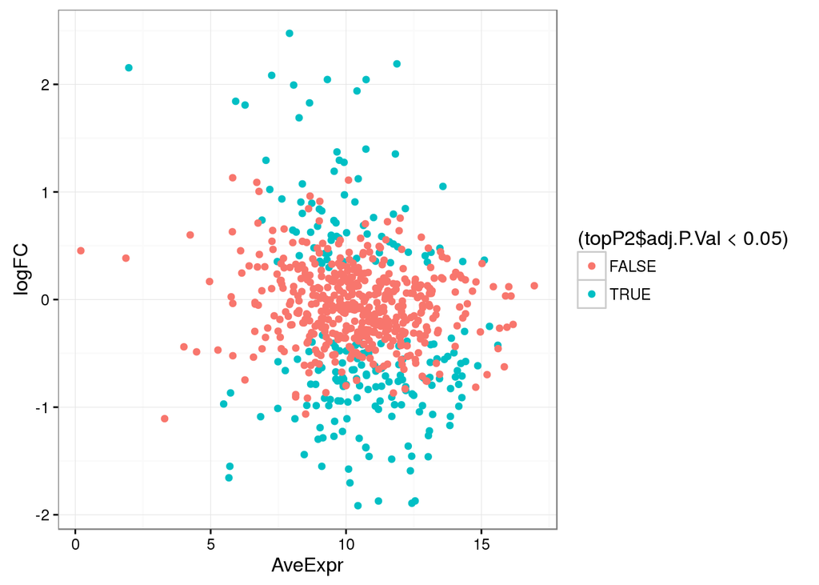

```r
ggplot(topP2, aes(x=AveExpr, y=logFC, col=(topP2$adj.P.Val<0.05))) + geom_point() + theme_bw()
```

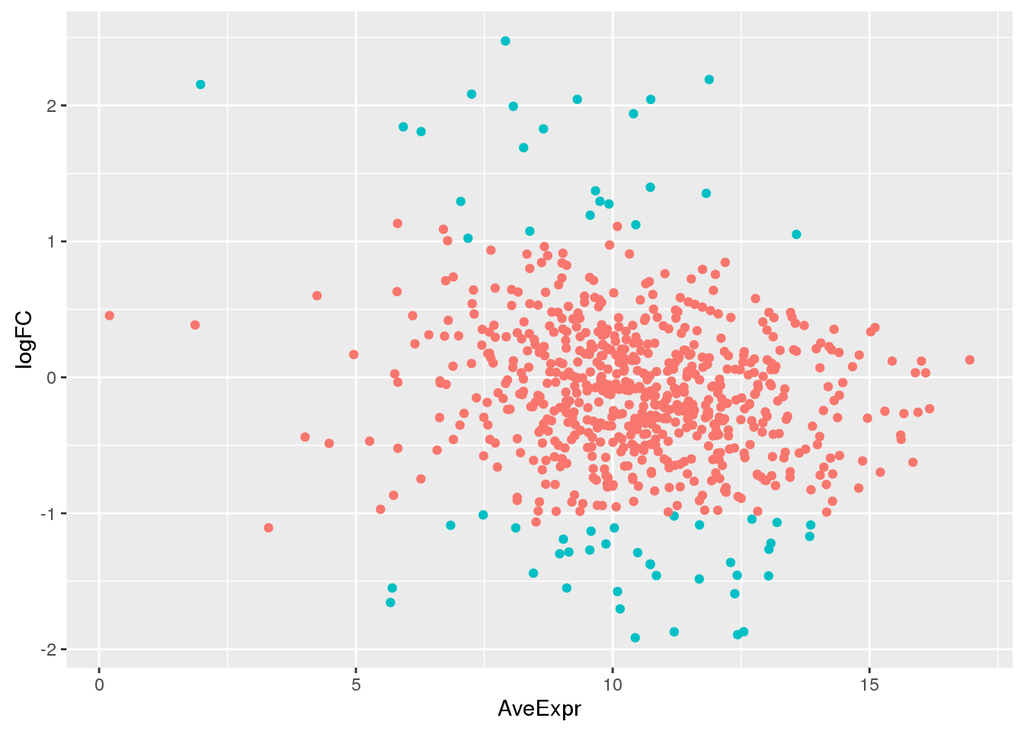

```r
ggplot(topP2, aes(x=AveExpr, y=logFC, col=((abs(topP2$logFC)>1)&(topP2$adj.P.Val<0.05)))) + geom_point() + theme(legend.position="none")
```

Gráfico 2

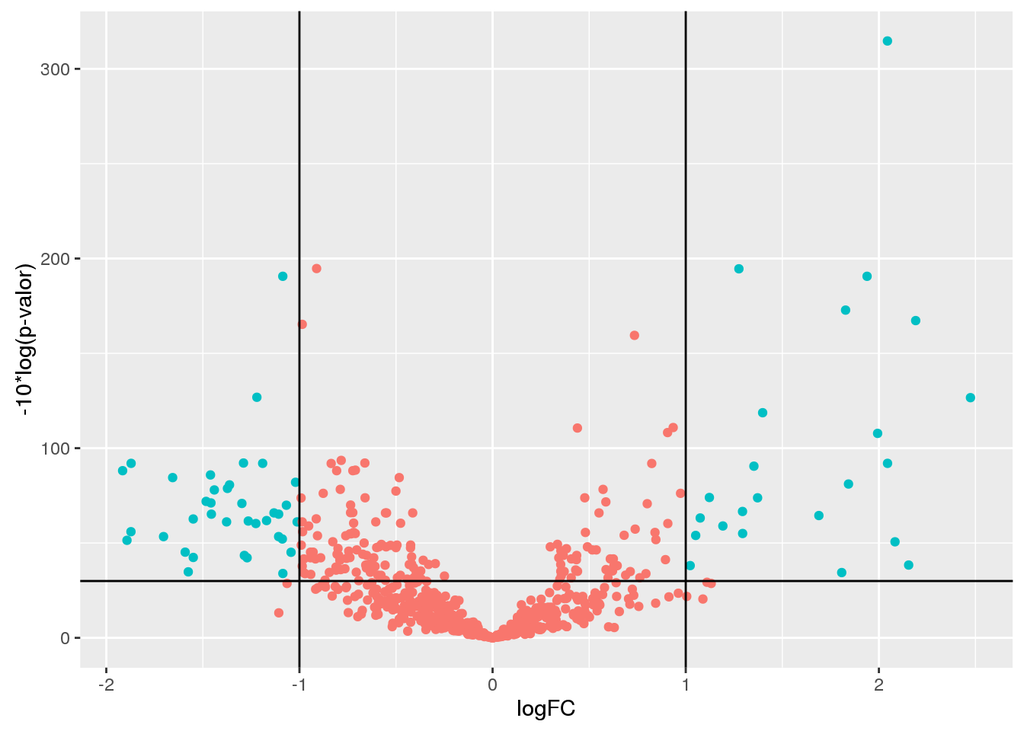

```r
ggplot(topP2, aes(x=logFC, y=(-(10*log(adj.P.Val))), col=((abs(topP2$logFC)>1)&((-10*log(topP2$adj.P.Val))>-10*log(0.05))))) + geom_point() + geom_vline(xintercept = c(-1,1)) + geom_hline(yintercept = -10*log(0.05))  + ylab("-10*log(p-valor)") + theme(legend.position="none") #+ theme_bw()
```

```r
require(gridExtra)
```

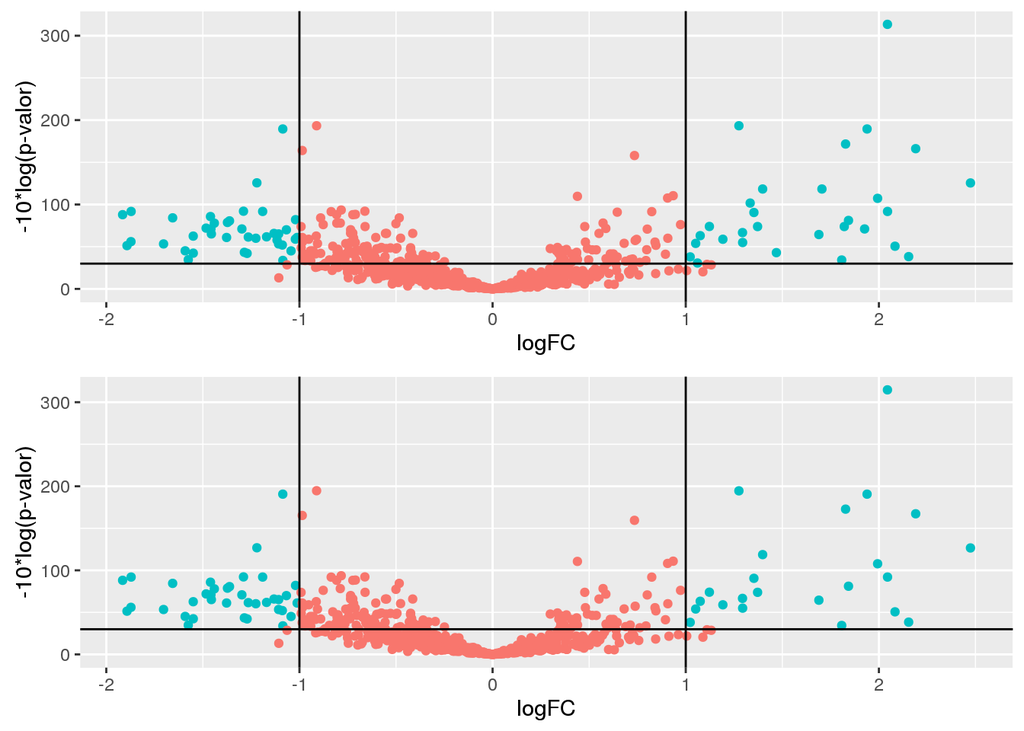

```r
plot1=ggplot(topP, aes(x=logFC, y=(-(10*log(adj.P.Val))), col=((abs(topP$logFC)>1)&((-10*log(topP$adj.P.Val))>-10*log(0.05))))) + geom_point() + geom_vline(xintercept = c(-1,1)) + geom_hline(yintercept = -10*log(0.05))  + ylab("-10*log(p-valor)") + theme(legend.position="none")

plot2=ggplot(topP2, aes(x=logFC, y=(-(10*log(adj.P.Val))), col=((abs(topP2$logFC)>1)&((-10*log(topP2$adj.P.Val))>-10*log(0.05))))) + geom_point() + geom_vline(xintercept = c(-1,1)) + geom_hline(yintercept = -10*log(0.05))  + ylab("-10*log(p-valor)") + theme(legend.position="none") #+ theme_bw()

grid.arrange(plot1, plot2, ncol=1)
```